# SALES & ADVERTISING

Rahel Joycelyn Hutagalung

2026-08-27

# Pemanggilan *Packages*

```r
install.packages("https://cran.r-project.org/src/contrib/Archive/orcutt/orcutt_2.1.tar.gz", repos = NULL, type = "source")
#install.packages("orcutt")
#install.packages("HoRM")
```

```r
library(dplyr)
library(TTR)
library(forecast)
library(lmtest) #digunakan untuk uji formal pendeteksian autokorelasi
library(orcutt) #untuk membuat model regresi Cochrane-Orcutt
library(HoRM) #untuk membuat model regresi Hildreth-Lu
```

# Input Data

Data yang digunakan dalam kesempatan kali ini adalah data Sales dan Advertising.

```r
sales <- c(11.7, 12, 12.3, 12.8, 13.1, 13.6, 13.9, 14.4, 14.7, 15.3, 15.5, 15.8, 16.1, 16.6, 16.9, 16.7, 16.9, 17.4, 17.6, 17.9, 18, 17.9, 18, 18.2, 18.2, 18.3, 18.6, 19.2, 19.3, 19.5, 19.2, 19.3, 19.5, 20, 20, 19.9, 19.8, 19.9, 20.2, 21)
advertising <- c(9.4, 9.6, 10, 10.4, 10.8, 10.9, 11.7, 12.2, 12.5, 12.9, 13, 13.2, 13.8, 14.2, 14.6, 14.4, 15, 15.4, 15.7, 15.9, 15.9, 16, 16.3, 16.2, 16.8, 17.3, 17.6, 18.1, 18.3, 18.5, 18.7, 18.9, 19.2, 20, 20, 20.3, 20.4, 21, 21.5, 22.1)
dtsalesadv <- data.frame(sales, advertising)
dtsalesadv
```

```
##    sales advertising
## 1   11.7         9.4
## 2   12.0         9.6
## 3   12.3        10.0
## 4   12.8        10.4
## 5   13.1        10.8
## 6   13.6        10.9
## 7   13.9        11.7
## 8   14.4        12.2
## 9   14.7        12.5
## 10  15.3        12.9
## 11  15.5        13.0
## 12  15.8        13.2
## 13  16.1        13.8
## 14  16.6        14.2
```

[output cut: 26 more lines]

# Eksplorasi Data

Sebelum melakukan regresi, akan diperlihatkan *plot time-series* dari Sales dan Advertising.

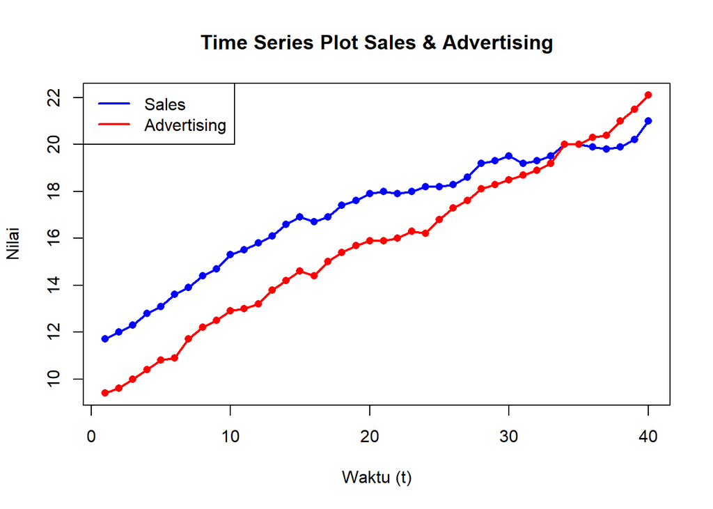

```r
# Menggabungkan dua objek time series
sales.ts <- ts(dtsalesadv$sales)
adv.ts   <- ts(dtsalesadv$advertising)

# Time series plot dengan 2 garis
ts.plot(sales.ts, adv.ts,
        col = c("blue", "red"),
        lwd = 2,
        xlab = "Waktu (t)",
        ylab = "Nilai",
        main = "Time Series Plot Sales & Advertising")

# Menambahkan titik dan legenda
points(sales.ts, col = "blue", pch = 16)
points(adv.ts, col = "red", pch = 16)
legend("topleft",
       legend = c("Sales", "Advertising"),
       col = c("blue", "red"),
       lty = 1,
       lwd = 2)
```

Selanjutnya akan dilakukan ramalan dan pemulusan dengan metode DMA dan DES karena terlihat pada plot di atas menunjukkan adanya *trend*.

```r
dt.sma <- SMA(sales.ts, n=3)
dma <- SMA(dt.sma, n = 3)
At <- 2*dt.sma - dma
Bt <- 2/(3-1)*(dt.sma - dma)
dt.dma<- At+Bt
dt.ramal<- c(NA, dt.dma)

t = 1:5
f = c()

for (i in t) {
  f[i] = At[length(At)] + Bt[length(Bt)]*(i)
}
```

```r
dt.gab <- cbind(aktual = c(sales.ts,rep(NA,5)),
                pemulusan1 = c(dt.sma,rep(NA,5)),
                pemulusan2 = c(dt.dma, rep(NA,5)),
                At = c(At, rep(NA,5)),
                Bt = c(Bt,rep(NA,5)),
                ramalan = c(dt.ramal, f[-1]))
dt.gab
```

```
##       aktual pemulusan1 pemulusan2       At            Bt  ramalan
##  [1,]   11.7         NA         NA       NA            NA       NA
##  [2,]   12.0         NA         NA       NA            NA       NA
##  [3,]   12.3   12.00000         NA       NA            NA       NA
##  [4,]   12.8   12.36667         NA       NA            NA       NA
##  [5,]   13.1   12.73333   13.46667 13.10000  3.666667e-01       NA
##  [6,]   13.6   13.16667   13.98889 13.57778  4.111111e-01 13.46667
##  [7,]   13.9   13.53333   14.31111 13.92222  3.888889e-01 13.98889
##  [8,]   14.4   13.96667   14.78889 14.37778  4.111111e-01 14.31111
##  [9,]   14.7   14.33333   15.11111 14.72222  3.888889e-01 14.78889
## [10,]   15.3   14.80000   15.66667 15.23333  4.333333e-01 15.11111
## [11,]   15.5   15.16667   15.96667 15.56667  4.000000e-01 15.66667
## [12,]   15.8   15.53333   16.26667 15.90000  3.666667e-01 15.96667
## [13,]   16.1   15.80000   16.40000 16.10000  3.000000e-01 16.26667
## [14,]   16.6   16.16667   16.83333 16.50000  3.333333e-01 16.40000
```

[output cut: 31 more lines]

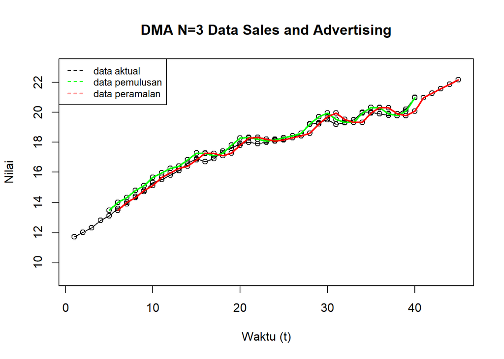

```r
#Plot time series
ts.plot(dt.gab[,1], xlab="Waktu (t)", ylab="Nilai",
        main= "DMA N=3 Data Sales and Advertising", ylim=c(9,23))
points(dt.gab[,1])
points(dt.gab[,3])
points(dt.gab[,6])
lines(dt.gab[,3],col="green",lwd=2)
lines(dt.gab[,6],col="red",lwd=2)
legend("topleft",c("data aktual","data pemulusan","data peramalan"),
       lty=8, col=c("black","green","red"), cex=0.8)
```

Selanjutnya akan dilihat keakuratan dari metode DMA (Sales)

```r
#Menghitung nilai keakuratan
error.dma = sales.ts-dt.ramal[1:length(sales.ts)]
SSE.dma = sum(error.dma[6:length(sales.ts)]^2)
MSE.dma = mean(error.dma[6:length(sales.ts)]^2)
MAPE.dma = mean(abs((error.dma[6:length(sales.ts)]/sales.ts[6:length(sales.ts)])*100))

akurasi.dma <- matrix(c(SSE.dma, MSE.dma, MAPE.dma))
row.names(akurasi.dma)<- c("SSE", "MSE", "MAPE")
colnames(akurasi.dma) <- c("Akurasi m = 3")
akurasi.dma
```

```
##      Akurasi m = 3
## SSE      4.1285185
## MSE      0.1179577
## MAPE     1.4379655
```

Selanjutnya akan digunakan metode *Double Exponential Smoothing* dengan cara sebagai berikut.

Pertama akan data akan dibagi menjadi data *training* dan data *testing*.

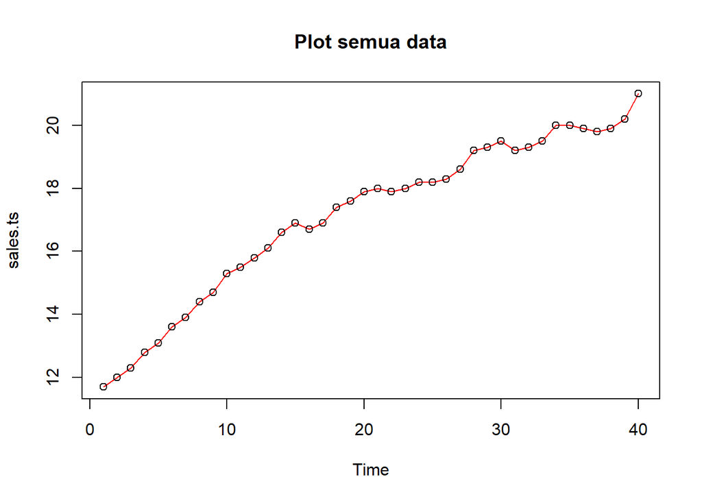

```r
#membagi training dan testing
training<-dtsalesadv[1:32, 1]
testing<-dtsalesadv[33:40, 1]

#data time series
training.ts<-ts(training)
testing.ts<-ts(testing,start=33)

#eksplorasi data
plot(sales.ts, col="red",main="Plot semua data")
points(sales.ts)
```

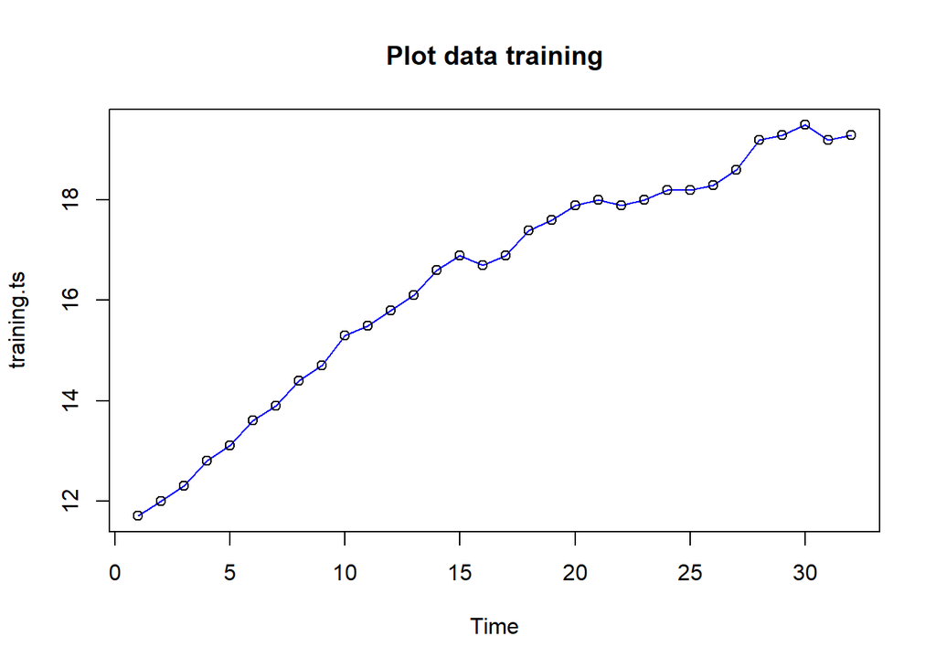

```r
plot(training.ts, col="blue",main="Plot data training")
points(training.ts)
```

Selanjutnya akan dilakukan pemulusan dengan DES, kali ini langsung dicari lambda dan gamma optimum sebagai berikut. Nilai lambda dan gamma optimum dapat dilihat pada smoothing parameters alpha untuk nilai lambda dan beta untuk nilai gamma.

```r
#Lamda dan gamma optimum
des.opt<- HoltWinters(training.ts, gamma = FALSE)
des.opt
```

```
## Holt-Winters exponential smoothing with trend and without seasonal component.
##
## Call:
## HoltWinters(x = training.ts, gamma = FALSE)
##
## Smoothing parameters:
##  alpha: 1
##  beta : 0.1544962
##  gamma: FALSE
##
## Coefficients:
##         [,1]
## a 19.3000000
## b  0.1299314
```

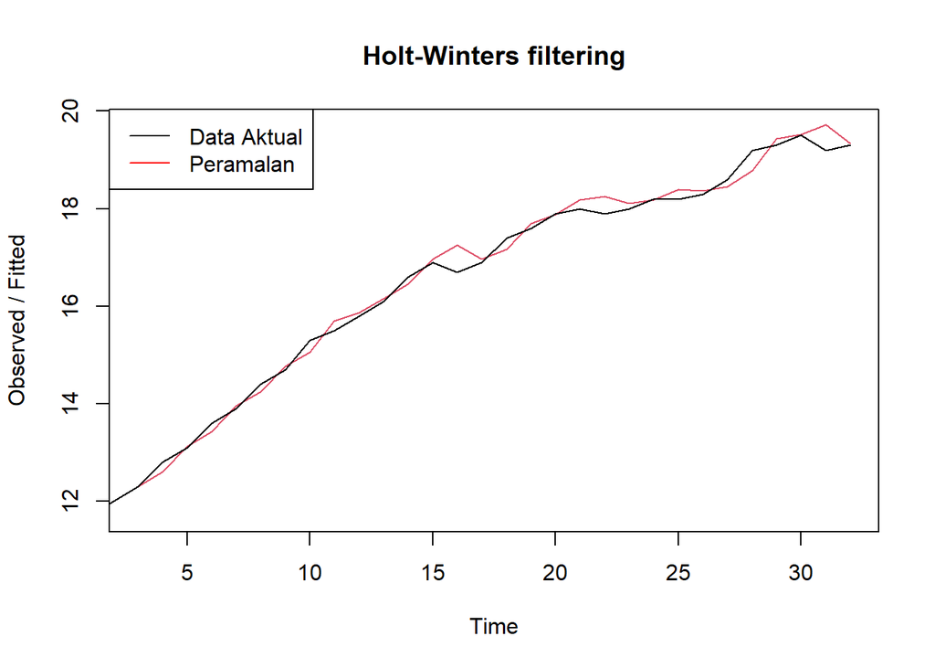

```r
plot(des.opt)
legend("topleft", c("Data Aktual", "Peramalan"), col = c("black", "red"),
       lty = c(1,1))
```

```r
#ramalan
ramalandesopt<- forecast(des.opt, h=8)
ramalandesopt
```

```
##    Point Forecast    Lo 80    Hi 80    Lo 95    Hi 95
## 33       19.42993 19.16043 19.69943 19.01776 19.84210
## 34       19.55986 19.14823 19.97149 18.93033 20.18940
## 35       19.68979 19.14768 20.23191 18.86070 20.51889
## 36       19.81973 19.14931 20.49014 18.79442 20.84503
## 37       19.94966 19.14991 20.74940 18.72655 21.17276
## 38       20.07959 19.14804 21.01113 18.65491 21.50426
## 39       20.20952 19.14300 21.27604 18.57841 21.84063
## 40       20.33945 19.13440 21.54450 18.49648 22.18242
```

Selanjutnya akan dicari akurasi dari metode DES.

```r
ssedes.train<-des.opt$SSE
msedes.train<-ssedes.train/length(training.ts)
sisaandes<-ramalandesopt$residuals
head(sisaandes)
```

```
## Time Series:
## Start = 1
## End = 6
## Frequency = 1
## [1]          NA          NA  0.00000000  0.20000000 -0.03089924  0.17387458
```

```r
mapedes.train <- sum(abs(sisaandes[3:length(training.ts)]/training.ts[3:length(training.ts)])*100)/length(training.ts)

akurasides.opt <- matrix(c(ssedes.train,msedes.train,mapedes.train))
row.names(akurasides.opt)<- c("SSE", "MSE", "MAPE")
colnames(akurasides.opt) <- c("Akurasi lamda dan gamma optimum")
akurasides.opt
```

```
##      Akurasi lamda dan gamma optimum
## SSE                       1.32286823
## MSE                       0.04133963
## MAPE                      0.85882804
```

```r
#Akurasi data testing
selisihdesopt<-ramalandesopt$mean-testing.ts
selisihdesopt
```

```
## Time Series:
## Start = 33
## End = 40
## Frequency = 1
## [1] -0.070068618 -0.440137236 -0.310205854 -0.080274472  0.149656909
## [6]  0.179588291  0.009519673 -0.660548945
```

```r
SSEtestingdesopt<-sum(selisihdesopt^2)
MSEtestingdesopt<-sum(selisihdesopt^2)/length(testing.ts)
MAPEtestingdesopt<-sum(abs(selisihdesopt/testing.ts)*100)/length(testing.ts)

akurasiDesTesting <- matrix(c(sum(selisihdesopt^2),MSEtestingdesopt,MAPEtestingdesopt))
row.names(akurasiDesTesting)<- c("SSE", "MSE", "MAPE")
colnames(akurasiDesTesting) <- c("Akurasi lamda dan gamma optimum")
akurasiDesTesting
```

```
##      Akurasi lamda dan gamma optimum
## SSE                       0.79236674
## MSE                       0.09904584
## MAPE                      1.17066575
```

Setelah didapatkan nilai akurasi untuk metode DMA dan DES, selanjutnya akan dibandingkan keakuratan antar metode keduanya.

```r
cbind(akurasi.dma, akurasides.opt)
```

```
##      Akurasi m = 3 Akurasi lamda dan gamma optimum
## SSE      4.1285185                      1.32286823
## MSE      0.1179577                      0.04133963
## MAPE     1.4379655                      0.85882804
```

Berdasarkan perbandingan akurasi tersebut, terlihat nilai SSE, MSE, dan MAPE metode DES lebih kecil dibandingkan dengan metode DMA. Oleh karena itu, metode peramalan dan pemulusan yang terbaik antara keduanya adalah dengan metode DES.

Setelah melakukan peramalan, data yang telah dimasukkan kemudian dieksplorasi. Eksplorasi pertama yang dilakukan adalah dengan menggunakan *scatter plot*.

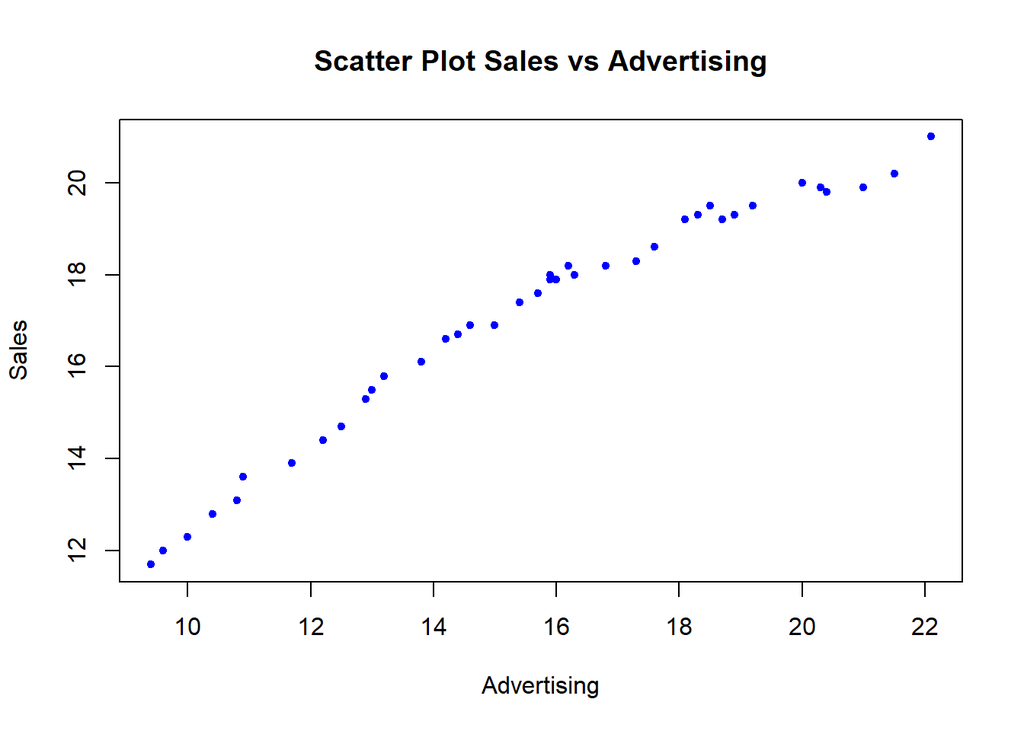

```r
#Eksplorasi Data
#Pembuatan Scatter Plot
plot(advertising,sales, pch = 20, col = "blue",
     main = "Scatter Plot Sales vs Advertising",
     xlab = "Advertising",
     ylab = "Sales")
```

```r
#Menampilkan Nilai Korelasi
cor(advertising,sales)
```

```
## [1] 0.9795849
```

Berdasarkan scatter plot di atas, terlihat adanya hubungan / korelasi positif antara peubah advertising dengan nilai sales, terlihat titik-titik pada plot yang naik ke arah kanan atas. Hal tersebut juga diperkuat dengan hasil perhitungan aplikasi `R` di mana didapatkan nilai korelasi sebesar $0.9795849$.

Setalah mengetahui adanya hubungan antar dua peubah, maka model regresi dapat ditentukan.

# Regresi

```r
#Pembuatan Model Regresi
#model regresi
model<- lm(sales~advertising, data = dtsalesadv)
summary(model)
```

```
##
## Call:
## lm(formula = sales ~ advertising, data = dtsalesadv)
##
## Residuals:
##      Min       1Q   Median       3Q      Max
## -1.03758 -0.40343  0.08933  0.45674  0.74036
##
## Coefficients:
##             Estimate Std. Error t value Pr(>|t|)
## (Intercept)  5.96513    0.38092   15.66   <2e-16 ***
## advertising  0.71035    0.02365   30.04   <2e-16 ***
## ---
## Signif. codes:  0 '***' 0.001 '**' 0.01 '*' 0.05 '.' 0.1 ' ' 1
##
## Residual standard error: 0.527 on 38 degrees of freedom
## Multiple R-squared:  0.9596, Adjusted R-squared:  0.9585
## F-statistic: 902.3 on 1 and 38 DF,  p-value: < 2.2e-16
```

Model yang dihasilkan adalah
$$Sales=5.96513+0.71035Advertising$$
Berdasarkan ringkasan model dapat diketahui bahwa hasil uji F memiliki *p-value* < 2.2e-16 $\alpha$ (5%). Artinya, setiap peningkatan satu satuan advertising diperkirakan akan meningkatkan sales sebesar 0.71035 satuan. Selanjutnya, nilai R² sebesar 0.9596 menunjukkan bahwa sebesar 95.96% variasi sales dapat dijelaskan oleh variabel advertising, sedangkan 4.04% sisanya dijelaskan oleh faktor lain di luar model. Nilai Adjusted R² sebesar 0.9585 juga menunjukkan bahwa model memiliki kemampuan penjelasan yang sangat baik. Namun, kita perlu melakukan uji terhadap sisaannya seperti berikut ini.

```r
#sisaan dan fitted value
sisaan<- residuals(model)
fitValue<- predict(model)
length(sisaan)
```

```
## [1] 40
```

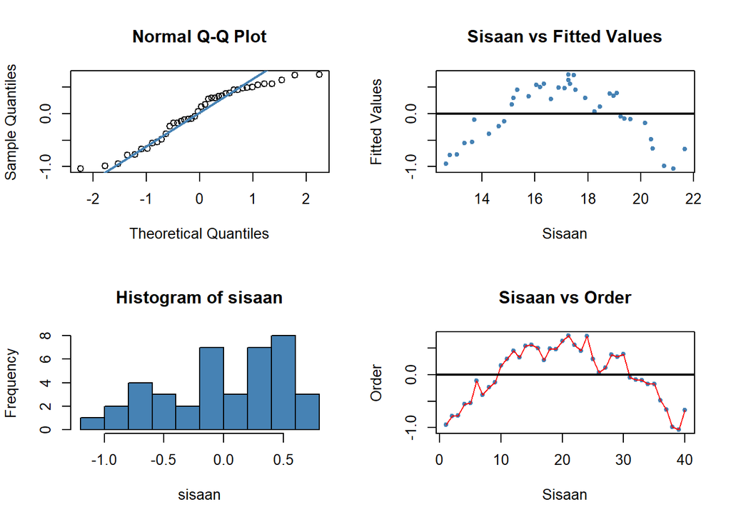

```r
#Diagnostik dengan eksploratif
par(mfrow = c(2,2))
qqnorm(sisaan)
qqline(sisaan, col = "steelblue", lwd = 2)
plot(fitValue, sisaan, col = "steelblue", pch = 20, xlab = "Sisaan", ylab = "Fitted Values", main = "Sisaan vs Fitted Values")
abline(a = 0, b = 0, lwd = 2)
hist(sisaan, col = "steelblue")
plot(seq(1,40,1), sisaan, col = "steelblue", pch = 20, xlab = "Sisaan", ylab = "Order", main = "Sisaan vs Order")
lines(seq(1,40,1), sisaan, col = "red")
abline(a = 0, b = 0, lwd = 2)
```

Dua plot di samping kiri digunakan untuk melihat apakah sisaan menyebar normal. Normal Q-Q Plot di atas menunjukkan bahwa sisaan cenderung menyebar normal, tetapi histogram dari sisaan tidak menunjukkan demikian. Selanjutnya, dua plot di samping kanan digunakan untuk melihat autokorelasi. Plot Sisaan vs *Fitted Value* dan Plot Sisaan vs *Order* menunjukkan adanya pola pada sisaan. Untuk lebih lanjut akan digunakan uji formal melihat normalitas sisaan dan plot ACF dan PACF untuk melihat apakah ada autokorelasi atau tidak.

```r
#Melihat Sisaan Menyebar Normal/Tidak
#H0: sisaan mengikuti sebaran normal
#H1: sisaan tidak mengikuti sebaran normal
shapiro.test(sisaan)
```

```
##
##  Shapiro-Wilk normality test
##
## data:  sisaan
## W = 0.93205, p-value = 0.0188
```

```r
ks.test(sisaan, "pnorm", mean=mean(sisaan), sd=sd(sisaan))
```

```
##
##  Asymptotic one-sample Kolmogorov-Smirnov test
##
## data:  sisaan
## D = 0.15458, p-value = 0.2948
## alternative hypothesis: two-sided
```

Berdasarkan uji formal Shapiro-Wilk dan Kolmogorov-Smirnov, diperoleh hasil yang berbeda. Uji Shapiro-Wilk menghasilkan p-value sebesar 0,0188 < α (5%), sehingga H₀ ditolak dan terdapat bukti bahwa sisaan tidak berdistribusi normal. Sementara itu, uji Kolmogorov-Smirnov menghasilkan p-value sebesar 0.2948 > α (5%), sehingga H₀ gagal ditolak dan tidak terdapat cukup bukti bahwa sisaan menyimpang dari distribusi normal. Dengan demikian, hasil uji formal menunjukkan adanya ketidakkonsistenan dalam asumsi normalitas sisaan, sehingga perlu mempertimbangkan hasil diagnostik lainnya.

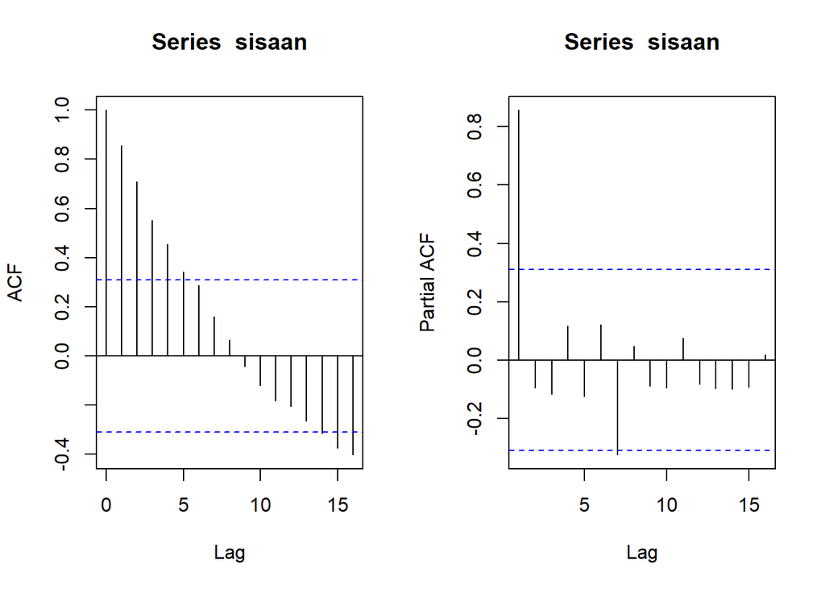

```r
#ACF dan PACF identifikasi autokorelasi
par(mfrow = c(1,2))
acf(sisaan)
pacf(sisaan)
```

Berdasarkan plot ACF, terdapat beberapa lag awal yang berada di luar batas signifikansi, yang mengindikasikan adanya autokorelasi pada sisaan. Sementara itu, pada plot PACF sebagian besar lag berada dalam batas signifikansi, meskipun terdapat beberapa lag yang mendekati atau melewati batas tersebut. Oleh karena itu, terdapat indikasi autokorelasi pada sisaan sehingga selanjutnya dilakukan uji formal Durbin-Watson untuk memastikan keberadaan autokorelasi.

```r
#Deteksi autokorelasi dengan uji-Durbin Watson
#H0: tidak ada autokorelasi
#H1: ada autokorelasi
dwtest(model)
```

```
##
##  Durbin-Watson test
##
## data:  model
## DW = 0.16204, p-value < 2.2e-16
## alternative hypothesis: true autocorrelation is greater than 0
```

Berdasarkan hasil DW Test, didapatkan nilai $DW = 0.16204$ dan *p-value* < $2.2e-16$. Berdasarkan tabel Durbin-Watson diperoleh nilai $DL = 1.4421$ dan $DU = 1.5444$. Nilai DW lebih kecil daripada nilai $DL$, yaitu $0.16204 < 1.4421$. Oleh karena itu, nilai DW berada pada daerah autokorelasi positif. Hasil tersebut juga didukung oleh p-value < 0.05, sehingga $H_0$ ditolak dan terdapat cukup bukti bahwa terjadi autokorelasi pada sisaan. Oleh karena itu, diperlukan penanganan autokorelasi.Penanganan yang akan digunakan menggunakan dua metode, yaitu Cochrane-Orcutt dan Hildret-Lu.

# Penanganan Autokorelasi

## Metode Cochrane-Orcutt

Penanganan metode Cochrane-Orcutt dapat dilakukan dengan bantuan packages Orcutt pada aplikasi `R` maupun secara manual. Berikut ini ditampilkan cara menggunakan bantuan `library` *packages* `Orcutt`.

```r
#Penanganan Autokorelasi Cochrane-Orcutt
modelCO<-cochrane.orcutt(model)
modelCO
```

```
## Cochrane-orcutt estimation for first order autocorrelation
##
## Call:
## lm(formula = sales ~ advertising, data = dtsalesadv)
##
##  number of interaction: 39
##  rho 0.903123
##
## Durbin-Watson statistic
## (original):    0.16204 , p-value: 8.935e-20
## (transformed): 1.93925 , p-value: 3.78e-01
##
##  coefficients:
## (Intercept) advertising
##   10.252375    0.488489
```

Hasil keluaran model setelah dilakukan penanganan adalah sebagai berikut.
$$\hat{y}_t=10.252375+0.488489x_t$$
Hasil juga menunjukkan bahwa nilai DW dan p-value meningkat menjadi $1.93925$ dan $3.78e-01$. Nilai DW sudah berada pada rentang $DU < DW < 4-DU$ atau $1.5444 < DW < 2.4556$. Hal tersebut juga didukung dengan nilai p-value > 0.05, artinya belum cukup bukti menyatakan bahwa sisaan terdapat autokorelasi pada taraf nyata 5%. Untuk nilai $\hat{\rho}$ optimum yang digunakan adalah $0.903123$. Nilai tersebut dapat diketahui dengan syntax berikut.

```r
#Rho optimum
rho<- modelCO$rho
rho
```

```
## [1] 0.9031233
```

Selanjutnya akan dilakukan transformasi secara manual dengan syntax berikut ini.

```r
sales
```

```
##  [1] 11.7 12.0 12.3 12.8 13.1 13.6 13.9 14.4 14.7 15.3 15.5 15.8 16.1 16.6 16.9
## [16] 16.7 16.9 17.4 17.6 17.9 18.0 17.9 18.0 18.2 18.2 18.3 18.6 19.2 19.3 19.5
## [31] 19.2 19.3 19.5 20.0 20.0 19.9 19.8 19.9 20.2 21.0
```

```r
sales[-1]
```

```
##  [1] 12.0 12.3 12.8 13.1 13.6 13.9 14.4 14.7 15.3 15.5 15.8 16.1 16.6 16.9 16.7
## [16] 16.9 17.4 17.6 17.9 18.0 17.9 18.0 18.2 18.2 18.3 18.6 19.2 19.3 19.5 19.2
## [31] 19.3 19.5 20.0 20.0 19.9 19.8 19.9 20.2 21.0
```

```r
#Transformasi Manual
n <- length(sales)
sales.trans <- sales[-1] - rho * sales[-n]
adv.trans   <- advertising[-1] - rho * advertising[-n]
modelCOmanual<- lm(sales.trans~adv.trans)
summary(modelCOmanual)
```

```
##
## Call:
## lm(formula = sales.trans ~ adv.trans)
##
## Residuals:
##      Min       1Q   Median       3Q      Max
## -0.37730 -0.14957  0.01257  0.10464  0.45315
##
## Coefficients:
##             Estimate Std. Error t value Pr(>|t|)
## (Intercept)  0.99322    0.14141   7.023 2.64e-08 ***
## adv.trans    0.48849    0.07543   6.476 1.43e-07 ***
## ---
## Signif. codes:  0 '***' 0.001 '**' 0.01 '*' 0.05 '.' 0.1 ' ' 1
##
## Residual standard error: 0.1868 on 37 degrees of freedom
## Multiple R-squared:  0.5313, Adjusted R-squared:  0.5186
## F-statistic: 41.94 on 1 and 37 DF,  p-value: 1.426e-07
```

```r
#Mencari Penduga Koefisien Regresi setelah Transformasi ke Persamaan Awal
b0bintang <- modelCOmanual$coefficients[1]
b0 <- b0bintang/(1-rho)
b1 <- modelCOmanual$coefficients[2]
b0
```

```
## (Intercept)
##    10.25237
```

```r
b1
```

```
## adv.trans
## 0.4884891
```

Hasil perhitungan koefisien regresi tersebut akan menghasilkan hasil yang sama dengan model yang dihasilkan menggunakan *packages*.

## Metode Hildreth-Lu

Penanganan kedua adalah menggunakan metode Hildreth-Lu. Metode ini akan mencari nilai SSE terkecil dan dapat dicari secara manual maupun menggunakan packages. Jika menggunakan packages, gunakan `library` *packages* `HORM`.

```r
library(HoRM)

# ambil y dan x (satu prediktor saja)
y <- dtsalesadv$sales
x <- dtsalesadv$advertising

# grid search rho 0–0.9
r <- seq(0, 0.9, by = 0.1)
tab <- data.frame(
  rho = r,
  SSE = sapply(r, function(rr) deviance(hildreth.lu(y, x, rr)))
)

tab            # tabel rho vs SSE
```

```
##    rho      SSE
## 1  0.0 9.561851
## 2  0.1 7.845710
## 3  0.2 6.330287
## 4  0.3 5.015381
## 5  0.4 3.900668
## 6  0.5 2.985599
## 7  0.6 2.269173
## 8  0.7 1.749430
## 9  0.8 1.422573
## 10 0.9 1.291395
```

```r
rho_hat <- tab$rho[which.min(tab$SSE)]   # rho terbaik
fit_hl  <- hildreth.lu(y, x, rho_hat)    # model final
summary(fit_hl)
```

```
##
## Call:
## lm(formula = y ~ x)
##
## Residuals:
##     Min      1Q  Median      3Q     Max
## -0.3749 -0.1461  0.0148  0.1057  0.4496
##
## Coefficients:
##             Estimate Std. Error t value Pr(>|t|)
## (Intercept)  1.01310    0.14198   7.135 1.87e-08 ***
## x            0.49358    0.07379   6.689 7.38e-08 ***
## ---
## Signif. codes:  0 '***' 0.001 '**' 0.01 '*' 0.05 '.' 0.1 ' ' 1
##
## Residual standard error: 0.1868 on 37 degrees of freedom
## Multiple R-squared:  0.5474, Adjusted R-squared:  0.5351
## F-statistic: 44.74 on 1 and 37 DF,  p-value: 7.382e-08
```

```r
#Penanganan Autokorelasi Hildreth lu
# Hildreth-Lu
hildreth.lu.func<- function(r, model){
  x <- model.matrix(model)[,-1]
  y <- model.response(model.frame(model))
  n <- length(y)
  t <- 2:n
  y <- y[t]-r*y[t-1]
  x <- x[t]-r*x[t-1]

  return(lm(y~x))
}

#Pencarian rho yang meminimumkan SSE
r <- c(seq(0.1,0.9, by= 0.1))
tab <- data.frame("rho" = r, "SSE" = sapply(r, function(i){deviance(hildreth.lu.func(i, model))}))
round(tab, 4)
```

```
##   rho    SSE
## 1 0.1 7.8457
## 2 0.2 6.3303
## 3 0.3 5.0154
## 4 0.4 3.9007
## 5 0.5 2.9856
## 6 0.6 2.2692
## 7 0.7 1.7494
## 8 0.8 1.4226
## 9 0.9 1.2914
```

Pertama-tama akan dicari di mana kira-kira $ρ$ yang menghasilkan SSE minimum. Pada hasil di atas terlihat $ρ$ minimum ketika 0.9. Namun, hasil tersebut masih kurang teliti sehingga akan dicari kembali $ρ$ yang lebih optimum dengan ketelitian yang lebih. Jika sebelumnya jarak antar $ρ$ yang dicari adalah 0.1, kali ini jarak antar $ρ$ adalah 0.001 dan dilakukan pada selang 0.8 sampai dengan 0.999.

```r
#Rho optimal di sekitar 0.999
rOpt <- seq(0.8,0.999, by= 0.001)
tabOpt <- data.frame("rho" = rOpt, "SSE" = sapply(rOpt, function(i){deviance(hildreth.lu.func(i, model))}))
head(tabOpt[order(tabOpt$SSE),])
```

```
##       rho      SSE
## 104 0.903 1.291226
## 105 0.904 1.291239
## 103 0.902 1.291248
## 106 0.905 1.291289
## 102 0.901 1.291304
## 107 0.906 1.291375
```

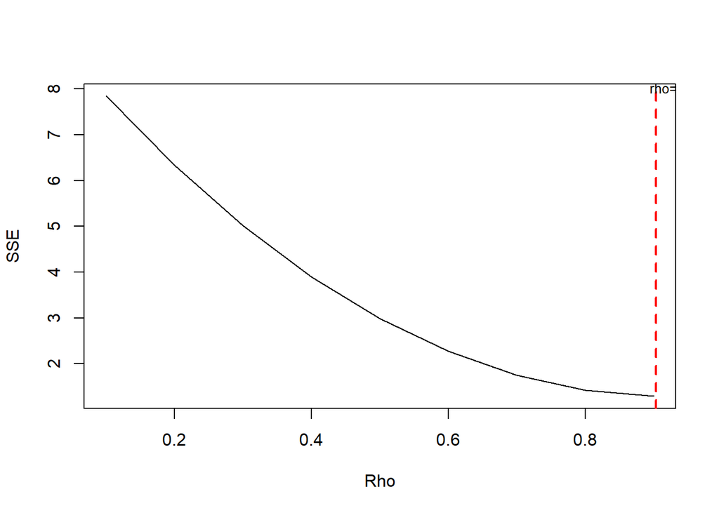

```r
#Grafik SSE optimum
par(mfrow = c(1,1))
plot(tab$SSE ~ tab$rho , type = "l", xlab = "Rho", ylab = "SSE")
abline(v = tabOpt[tabOpt$SSE==min(tabOpt$SSE),"rho"], lty = 2, col="red",lwd=2)
text(x=0.999, y=8, labels = "rho=0.999", pos = 2, cex = 0.8)
```

```r
#Model terbaik
modelHL <- hildreth.lu.func(0.999, model)
summary(modelHL)
```

```
##
## Call:
## lm(formula = y ~ x)
##
## Residuals:
##     Min      1Q  Median      3Q     Max
## -0.4763 -0.1480  0.0232  0.1228  0.4282
##
## Coefficients:
##             Estimate Std. Error t value Pr(>|t|)
## (Intercept)  0.08935    0.06064   1.474  0.14905
## x            0.48693    0.14837   3.282  0.00226 **
## ---
## Signif. codes:  0 '***' 0.001 '**' 0.01 '*' 0.05 '.' 0.1 ' ' 1
##
## Residual standard error: 0.2084 on 37 degrees of freedom
## Multiple R-squared:  0.2255, Adjusted R-squared:  0.2045
## F-statistic: 10.77 on 1 and 37 DF,  p-value: 0.002256
```

```r
#Transformasi Balik
cat("y = ", coef(modelHL)[1]/(1-0.999), "+", coef(modelHL)[2],"x", sep = "")
```

```
## y = 89.35474+0.4869287x
```

```r
#Deteksi autokorelasi
dwtest(modelHL)
```

```
##
##  Durbin-Watson test
##
## data:  modelHL
## DW = 1.6965, p-value = 0.1723
## alternative hypothesis: true autocorrelation is greater than 0
```

Terakhir, akan dibandingkan nilai SSE dari ketiga metode (metode awal, metode Cochrane-Orcutt, dan Hildreth-Lu).

```r
#Perbandingan
sseModelawal <- anova(model)$`Sum Sq`[-1]
sseModelCO <- anova(modelCOmanual)$`Sum Sq`[-1]
sseModelHL <- anova(modelHL)$`Sum Sq`[-1]
mseModelawal <- sseModelawal/length(sales)
mseModelCO <- sseModelCO/length(sales)
mseModelHL <- sseModelHL/length(sales)
akurasi <- matrix(c(sseModelawal,sseModelCO,sseModelHL,
                    mseModelawal,mseModelCO,mseModelHL),nrow=2,ncol=3,byrow = T)
colnames(akurasi) <- c("Model Awal", "Model Cochrane-Orcutt", "Model Hildreth-Lu")
row.names(akurasi) <- c("SSE","MSE")
akurasi
```

```
##     Model Awal Model Cochrane-Orcutt Model Hildreth-Lu
## SSE 10.5545322            1.29122545        1.60762112
## MSE  0.2638633            0.03228064        0.04019053
```

Berdasarkan hasil tersebut dapat diketahui bahwa hasil penanganan autokorelasi dengan metode Cochrane-Orcutt menghasilkan nilai SSE terkecil yaitu $1.29122545$, diikuti oleh metode Hildreth-Lu sebesar $1.60762112$. Kedua metode tersebut jauh lebih baik dalam meminimumkan galat dibandingkan model awal ketika autokorelasi masih terjadi, yaitu sebesar $10.5545322$.

# Simpulan

Autokorelasi yang terdapat pada data Sales dan Advertising terjadi akibat adanya korelasi di antara unsur penyusunnya. Indikator Sales yang erat hubungannya dengan perekonomian sangat rawan menjadi penyebab adanya autokorelasi. Adanya autokorelasi menyebabkan model regresi kurang baik karena akan meingkatkan galatnya. Autokorelasi dapat dideteksi secara eksploratif melalui plot sisaan, ACF, dan PACF, serta dengan uji formal Durbin-Watson. Namun, autokorelasi tersebut dapat ditangani dengan metode Cochrane-Orcutt dan Hildreth-Lu. Kedua metode berhasil menurunkan nilai galat model awal, dengan metode Cochrane-Orcutt memberikan hasil terbaik karena menghasilkan nilai SSE terkecil (1.29122545).

# Daftar Pustaka

Aprianto A, Debataraja NN, Imro’ah N. 2020. Metode cochrane-orcutt untuk mengatasi autokorelasi pada estimasi parameter ordinary least squares. *Bimaster : Buletin Ilmiah Matematika, Statistika dan Terapannya*. 9(1):95–102. doi:10.26418/bbimst.v9i1.38590.